# Identifying Fraud from Enron Emails

By: Courtney Ferguson Lee

June 29, 2017

## Introduction

The goal for this project was to identify persons of interest (POI’s) from a dataset of Enron employees. The dataset initially contained 146 observations across 21 features and a POI status label. There were 18 POI’s and 128 non-POI’s. I used a supervised machine learning algorithm to identify patterns in the email and financial data that separated POI’s from non-POI’s. The financial and email variables included:

| Financial Variables | Email Variables |
| --- | --- |
| bonus | email_address |
| deferral_payments | from_messages |
| deferred_income | from_poi_to_this_person |
| director_fees | from_this_person_to_poi |
| exer_stock_opts_over_tot | shared_receipt_with_poi |
| exercised_stock_options | to_messages |
| expenses |  |
| loan_advances |  |
| long_term_incentive |  |
| other |  |
| restricted_stock |  |
| restricted_stock_deferred |  |
| salary |  |
| salary_over_bonus |  |
| total_payments |  |
| total_stock_value |  |

Three outliers in the dataset needed to be removed: “TOTAL”, “THE TRAVEL AGENCY IN THE PARK”, and “LOCKHART EUGENE E”. The first two weren’t actual people, so they did not contribute to the model. Eugene Lockhart was missing data for all of his features, so he was removed as well. Because of the nature of the dataset, it was difficult to remove any outliers that varied significantly from the rest of the population. The dataset consisted of less than 150 people and there was a lot of missing data, as shown in the following chart:

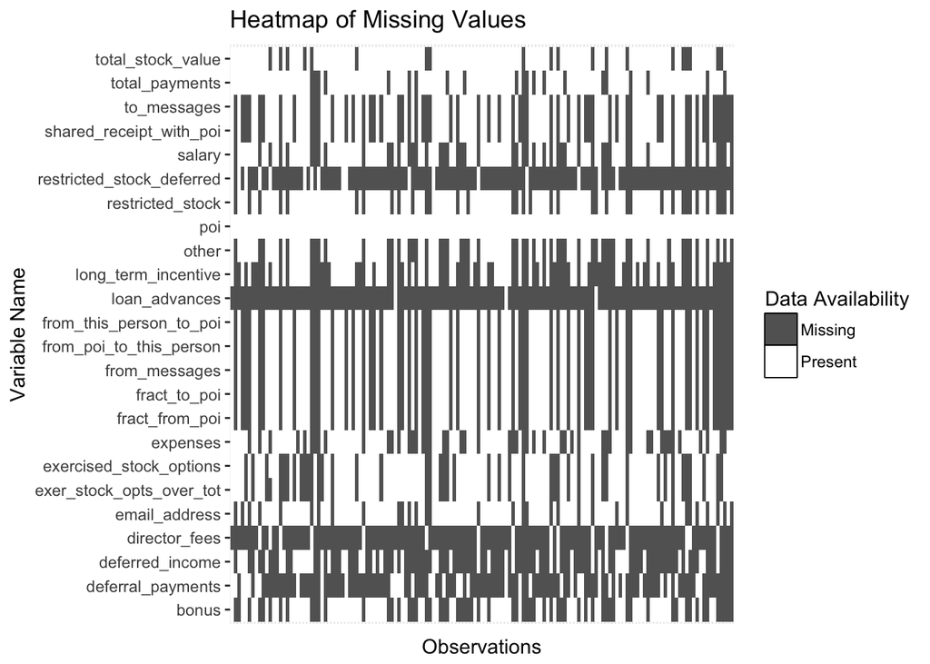

## Feature Engineering

I used Exploratory Data Analysis to identify / engineer the 9 features below to help create clearer boundaries for my classifier. I created two of the features: the fraction of emails sent to POI’s and the fraction of emails from POI’s. I did this because it did not make sense to use the raw number of emails to or from a POI. The total number of sent and received emails ranged from around 10 to over 10,000. To better compare human interactions, it made more sense to code this data as a proportion. When I created the scatterplot of the two features (further below), they created clear boundaries that helped improve my classifier.The fraction of emails sent to a POI (x-axis) below 16% and above 68% uniformly contained non-POI’s. The same was true for the fraction of emails from a POI (y-axis) below 2% and above 14%. These clear boundaries helped my classifier distinguish between POI’s and non-POI’s.

| Variable | Definition |
| --- | --- |
| salary | Guaranteed annual salary for each employee |
| bonus | Additional compensation tied to an employee’s performance review |
| total_stock_value | Total value of Enron stock an employee received as compensation |
| fract_from_poi | Fraction of total emails received from a poi |
| fract_to_poi | Fraction of total emails sent to a poi |
| director_fees | Compensation for attendance at board meetings |
| restricted_stock_deferred | Stock that was not fully transferrable until certain conditions were met |
| exercised_stock_options | Amount of Enron stock an employee bought or sold |
| expenses | Costs occurred by an employee while conducting business |

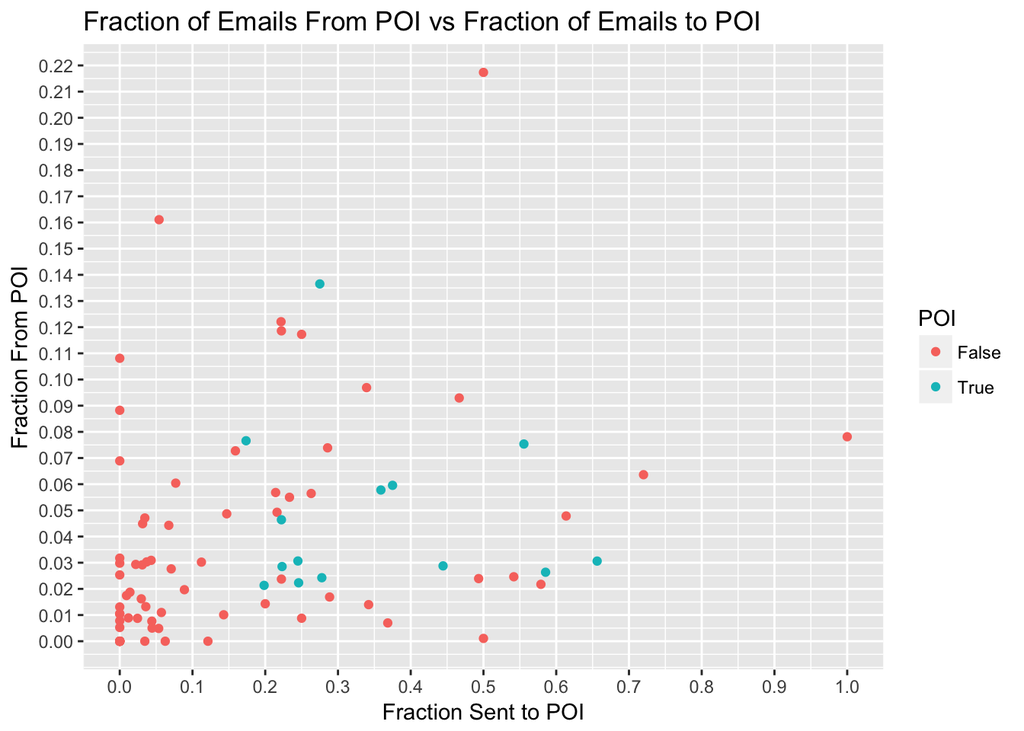

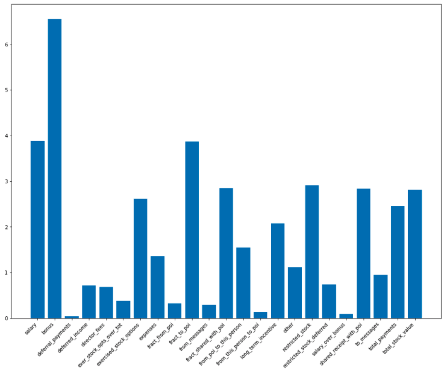

Below are the evaluation metrics for my final model with and without the fract_to_poi and fract_from_poi features. The results show that after adding the engineered features to the model, precision increased from 27% to 35% and recall increased from 44% to 78%. I also created the variables salary_over_bonus and exer_stock_opts_over_tot. When I tested them in my algorithm, their evaluation metrics were better than the original 7, but lower than fract_from_poi and fract_to_poi alone, so I omitted them. The results of adding those variables to my final algorithm (11 total features) are summarized below:

**Omitting fract_from_poi and fract_to_poi**

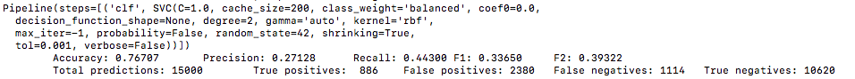

**Including fract_from_poi and fract_to_poi**

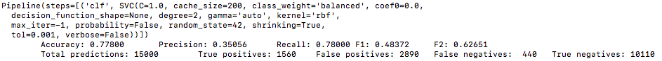

**Including fract_from_poi, fract_to_poi, salary_over_bonus and exer_stock_opts_over_tot**

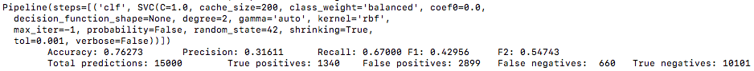

The plots below helped me further understand the underlying nature of the financial and email variables. The boxplot of financial variables helped me see that only Non-POI’s had director_fees and restricted_stock_deferred variables present. The emails boxplot made me think critically about how I could engineer new fractional email features which I eventually included in my classifier:

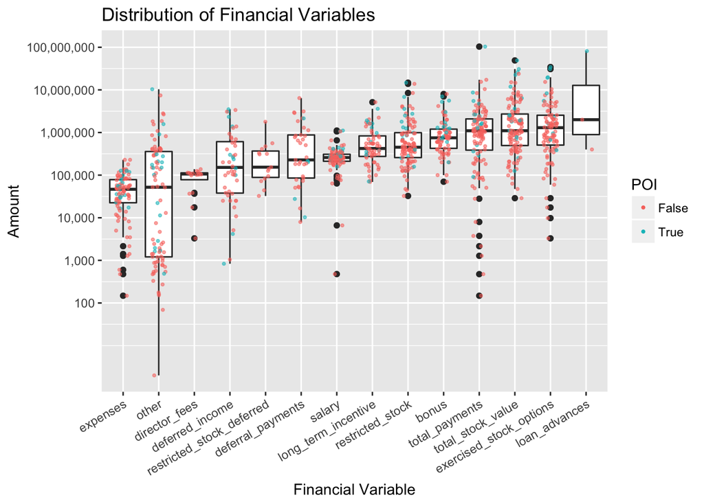

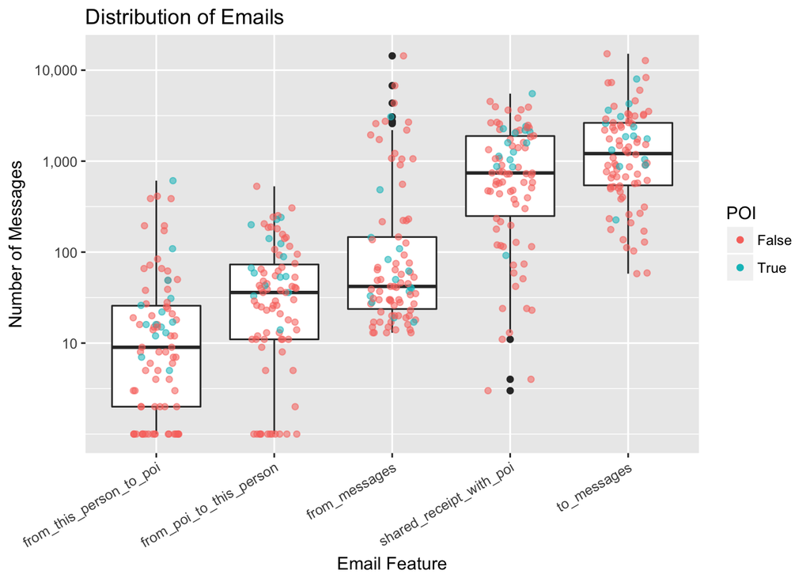

After identifying useful features, I scaled them before trying PCA in my model. I scaled the features because the ranges of the variables were too large and would throw off predictions. For instance, the range for fractional email variables ranged from 0.0 to 1.0 while exercised stock options varied from 1,000 to around 30,000,000. With such a large range, PCA would not be able to properly determine which variable accounted for most of the variance in the data. I created my own MinMaxScaler and applied it right after creating new features. It ensured that all variables ranged from 0 to 1. PCA allowed the data to speak for itself in a way. I also used GridSearchCV to tune the parameters of PCA itself. After testing out a range of 2 to 11 components for PCA I realized that I had better evaluation metrics without the transformation, so I excluded it.

## Algorithm Selection

Support Vector Machines had the best overall scores once I tuned the class_weight parameter to “balanced”. This was important because the dataset was very imbalanced. There were only 18 POI’s and 128 non-POI’s (125 once outliers were removed). Before tuning the class_weight parameter, the algorithm penalized mistakes to both classes equally. Adjusting the class_weight parameter remedied this. The original survey results are summarized below. I used the following features in each model:

- salary
- fract_to_poi
- fract_from_poi
- director_fees
- restricted_stock_deferred
- exercised_stock_options
- expenses
- total_stock_value

Classifier

Results

DecisionTree

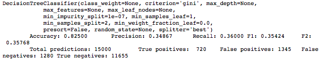

Naive Bayes

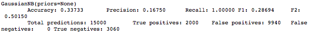

KNearest Neighbors

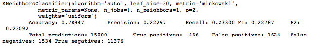

SupportVectorMachines

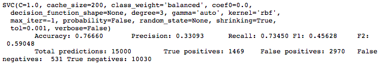

## Parameter Tuning

Tuning the parameters of an algorithm involves testing out different combinations of input arguments. These input arguments, known as hyperparamters are set before an algorithm is fit to data and affect the performance on an independent data set. These hyperparameters affect the performance of a model, including but not limited to its complexity, learning capacity, and speed. This is one way to “custom fit” an algorithm to the training data it is modeling. Parameter tuning is a way to adjust an algorithm at a high level prior to training. For instance, if you are using a DecisionTree Classifier and your model is underfitting to your data, you can adjust the min_samples_split hyperparameter to allow the model to make more granular splits and hence more closely fit the data.

Parameter tuning applies to both pre-processing steps like PCA and the algorithm chosen. I used GridSearchCV to accomplish this. It allowed me to try several different parameters in one shot as opposed to rerunning the algorithm every time I wanted to make an adjustment. I tried a range of 2-11 PCA components and found that PCA didn’t help my model much. When testing the DecisionTree classifier, I was able to experiment with different max_depths, split criteria and min_samples_splits. We calculated entropy for various scenarios in the lessons so I tried using that as an alternative criterion, but the results didn’t change much from baseline.

## Model Validation

Validation involves ensuring a model is effective on both training and testing data. One pitfall in validation is when you accidentally overfit your model to the training data. Overfitting is when your model performs well on training data but poorly on new testing data. This can happen if you don’t partition a large enough chunk for your testing set or when you use an overly-convoluted boundary when training.

## Conclusion

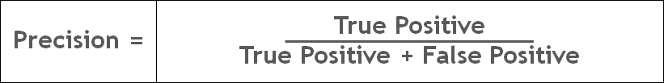

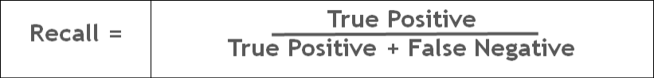

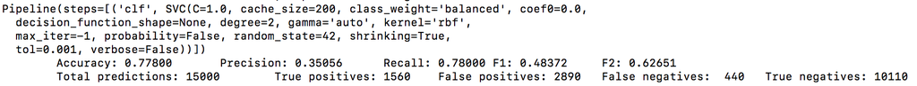